# Chapter 6. Analysis of longitudial data.

Today is:

```
## [1] "Thu Dec  3 23:50:38 2020"
```

#### Task 1. Chapter 8 analyses for RATS data.

Let’s start strait from long format data. Way to create that could be seen in [here](https://github.com/ZoomMan91/IODS-project/blob/master/meet_and_repeat.R). So, read the RATSL data.

```r
RATSL<-read.table(file="data/RATSL.txt",header=T)
RATSL$ID <- factor(RATSL$ID)
RATSL$Group <- factor(RATSL$Group)
head(RATSL)
```

```
##   ID Group WDs  BW time
## 1  1     1 WD1 240    1
## 2  2     1 WD1 225    1
## 3  3     1 WD1 245    1
## 4  4     1 WD1 260    1
## 5  5     1 WD1 255    1
## 6  6     1 WD1 260    1
```

```r
str(RATSL)
```

```
## 'data.frame':    176 obs. of  5 variables:
##  $ ID   : Factor w/ 16 levels "1","2","3","4",..: 1 2 3 4 5 6 7 8 9 10 ...
##  $ Group: Factor w/ 3 levels "1","2","3": 1 1 1 1 1 1 1 1 2 2 ...
##  $ WDs  : chr  "WD1" "WD1" "WD1" "WD1" ...
##  $ BW   : int  240 225 245 260 255 260 275 245 410 405 ...
##  $ time : int  1 1 1 1 1 1 1 1 1 1 ...
```

```r
table(RATSL$ID)
```

```
##
##  1  2  3  4  5  6  7  8  9 10 11 12 13 14 15 16
## 11 11 11 11 11 11 11 11 11 11 11 11 11 11 11 11
```

```r
summary(RATSL)
```

```
##        ID      Group      WDs                  BW             time
##  1      : 11   1:88   Length:176         Min.   :225.0   Min.   : 1.00
##  2      : 11   2:44   Class :character   1st Qu.:267.0   1st Qu.:15.00
##  3      : 11   3:44   Mode  :character   Median :344.5   Median :36.00
##  4      : 11                             Mean   :384.5   Mean   :33.55
##  5      : 11                             3rd Qu.:511.2   3rd Qu.:50.00
##  6      : 11                             Max.   :628.0   Max.   :64.00
##  (Other):110
```

The data was collected during nutrition studies on rats performed by Crower and Hand (1990). Group in the data denotes for diet used to feed animals. BW (body weight) was 11 times repeatedly measured in grams from each rat. Exact days of measurement were:

```
##  [1]  1  8 15 22 29 36 43 44 50 57 64
```

Number of rats:

```
## [1] 16
```

Graphical display of the data.

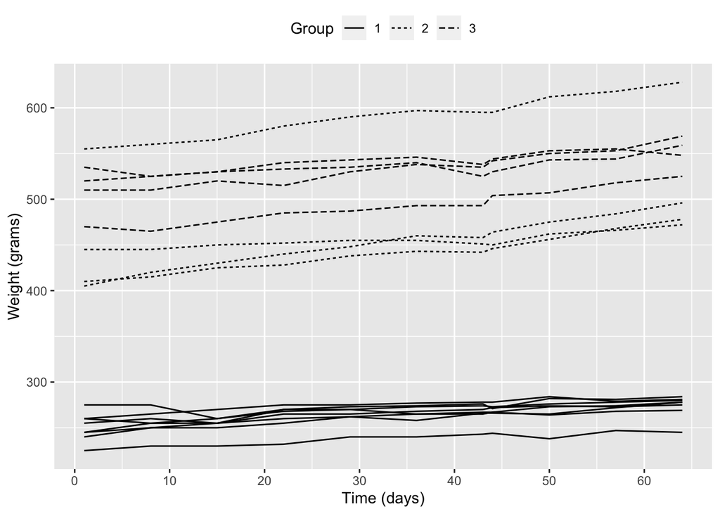

```r
ggplot(RATSL, aes(x = time, y = BW, group = ID)) +
  geom_line(aes(linetype = Group)) +
  scale_x_continuous(name = "Time (days)", breaks = seq(0, 60, 10)) +
  scale_y_continuous(name = "Weight (grams)") +
  theme(legend.position = "top")
```

In group 2 one rat had higher starting Body Weight and outstanding observations along the studies. Oppositely two animals in diet one and three respectively had starting weight lower than majority of animals within a group. One could deal with difference on the plot by standardizing records. So, only “progress” will be seen instead of real values.

Performing standardization and plotting again.

```r
RATSS <- RATSL %>%
  group_by(time) %>%
  mutate(stBW =(BW-mean(BW))/sd(BW)) %>%
  ungroup()
glimpse(RATSS)
```

```
## Rows: 176
## Columns: 6
## $ ID    <fct> 1, 2, 3, 4, 5, 6, 7, 8, 9, 10, 11, 12, 13, 14, 15, 16, 1, 2, 3,…
## $ Group <fct> 1, 1, 1, 1, 1, 1, 1, 1, 2, 2, 2, 2, 3, 3, 3, 3, 1, 1, 1, 1, 1, …
## $ WDs   <chr> "WD1", "WD1", "WD1", "WD1", "WD1", "WD1", "WD1", "WD1", "WD1", …
## $ BW    <int> 240, 225, 245, 260, 255, 260, 275, 245, 410, 405, 445, 555, 470…
## $ time  <int> 1, 1, 1, 1, 1, 1, 1, 1, 1, 1, 1, 1, 1, 1, 1, 1, 8, 8, 8, 8, 8, …
## $ stBW  <dbl> -1.0011429, -1.1203857, -0.9613953, -0.8421525, -0.8819001, -0.…
```

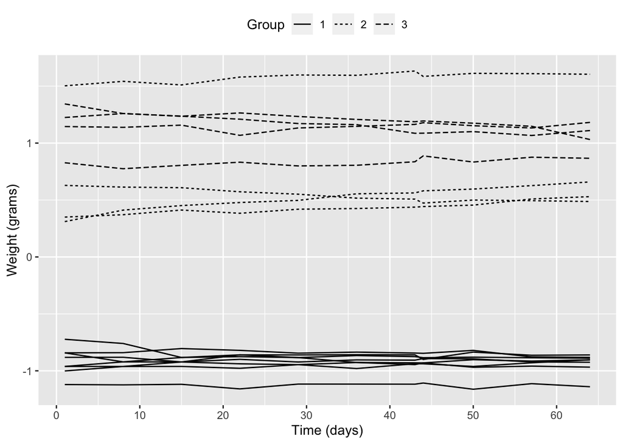

```r
ggplot(RATSS, aes(x = time, y = stBW, group = ID)) +
  geom_line(aes(linetype = Group)) +
  scale_x_continuous(name = "Time (days)", breaks = seq(0, 60, 10)) +
  scale_y_continuous(name = "Weight (grams)") +
  theme(legend.position = "top")
```

I would say outliers are still the same. Let’s construct mean profiles and boxplots.Number of days (measurement days).

```r
n <- RATSL$time %>% unique() %>% length()
n
```

```
## [1] 11
```

To construct mean profiles first one need to create summary data by group and day. Let’s do that and print data sammary.

```r
RATSS <- RATSL %>%
    group_by(Group, time) %>%
  summarise( mean =BW, se = BW ) %>%
  ungroup()
glimpse(RATSS)
```

```
## Rows: 176
## Columns: 4
## $ Group <fct> 1, 1, 1, 1, 1, 1, 1, 1, 1, 1, 1, 1, 1, 1, 1, 1, 1, 1, 1, 1, 1, …
## $ time  <int> 1, 1, 1, 1, 1, 1, 1, 1, 8, 8, 8, 8, 8, 8, 8, 8, 15, 15, 15, 15,…
## $ mean  <int> 240, 225, 245, 260, 255, 260, 275, 245, 250, 230, 250, 255, 260…
## $ se    <int> 240, 225, 245, 260, 255, 260, 275, 245, 250, 230, 250, 255, 260…
```

Now construct the plot.

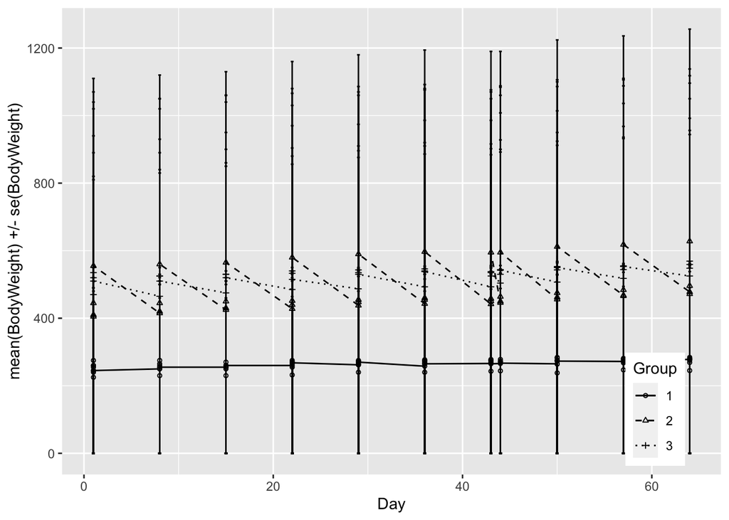

```r
ggplot(RATSS, aes(x = time, y = mean, linetype = Group, shape = Group)) +
  geom_line() +
  scale_linetype_manual(values = c(1,2,3)) +
  geom_point(size=1) +
  scale_shape_manual(values = c(1,2,3)) +
  geom_errorbar(aes(ymin = mean - se, ymax = mean + se, linetype="1"), width=0.3) +
  theme(legend.position = c(0.9,0.14)) +
  scale_y_continuous(name = "mean(BodyWeight) +/- se(BodyWeight)")+
  scale_x_continuous(name = "Day")
```

Looks ugly. Let’s do box plots instead. But, first we will take day 1 out as that measurement was done before special diet.

```r
RATSS1 <- RATSL %>%
  filter(time > 1) %>%
  group_by(Group, ID) %>%
  summarise( mean=mean(BW) ) %>%
  ungroup()
```

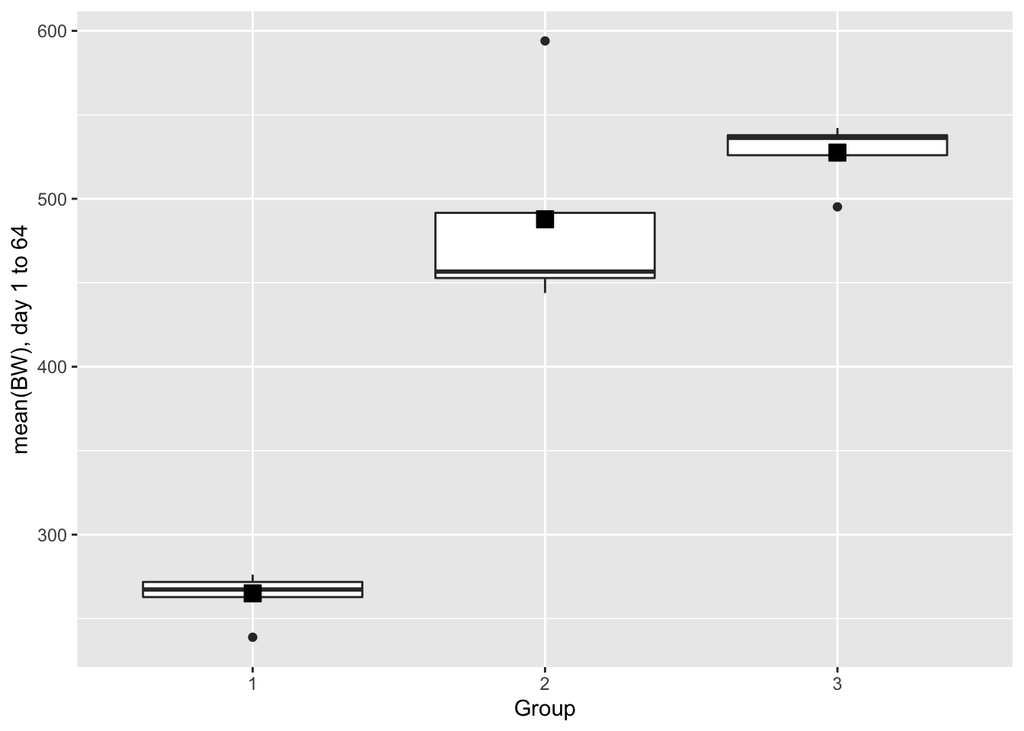

```r
ggplot(RATSS1, aes(x = Group, y = mean)) +
  geom_boxplot() +
  stat_summary(fun = "mean", geom = "point", shape=22, size=4, fill = "black") +
  scale_y_continuous(name = "mean(BW), day 1 to 64")+
  theme(legend.position = c(0.9,0.14))
```

Now it’s look nice. One outlier per each group. The largest variation seen in the second diet. Let’s filter outliers and re-do plotting.

```r
RATSS1f<-RATSS1 %>% filter((RATSS1$Group ==1 & RATSS1$mean>240 ) | (RATSS1$Group ==2 & RATSS1$mean<500) |(RATSS1$Group ==3 & RATSS1$mean>500))
summary(RATSS1f$mean)
```

```
##    Min. 1st Qu.  Median    Mean 3rd Qu.    Max.
##   261.7   267.5   276.2   373.3   457.5   542.2
```

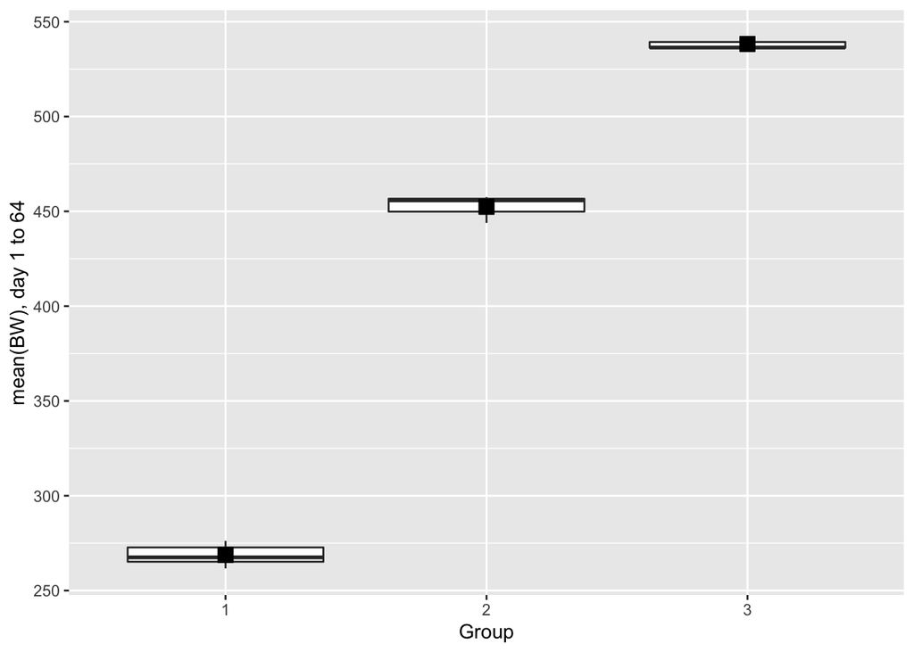

```r
ggplot(RATSS1f, aes(x = Group, y = mean)) +
  geom_boxplot() +
  stat_summary(fun = "mean", geom = "point", shape=22, size=4, fill = "black") +
  scale_y_continuous(name = "mean(BW), day 1 to 64")+
  theme(legend.position = c(0.9,0.14))
```

Now box-plots looks nice. After removing outliers we could see that mean of first diet is clearly lower then second and third. The highest is in the group three. Close variations seen in animals from first and second diets. Due to removal of rats observations from second group, previously detected variation was reduced.

According to the Book next we suppose to perform *t*-test. This will helps us to see difference between diets more precisely. Data has 3 groups, thus simple t.test could not be used in single run. Or I could not find good solution. We could check p-values from paired *t*-test straight using **pairwise_t_test function**. But, than *t*-test values are not shown. Google search result on complicated functions to extract confidence intervals and *t-tests* from **pairwise_t_test**. P-values are:

```r
RATSS1f %>%  pairwise_t_test(mean ~ Group,paired=F)
```

```
## # A tibble: 3 x 9
##   .y.   group1 group2    n1    n2        p p.signif    p.adj p.adj.signif
## * <chr> <chr>  <chr>  <int> <int>    <dbl> <chr>       <dbl> <chr>
## 1 mean  1      2          7     3 3.99e-13 ****     7.99e-13 ****
## 2 mean  1      3          7     3 8.71e-15 ****     2.61e-14 ****
## 3 mean  2      3          3     3 3.86e- 9 ****     3.86e- 9 ****
```

To see all needed variables I will perform pairwise test manually. Group 1 and 2:

```r
t.test(mean ~ Group, data = subset(RATSS1f,RATSS1f$Group==1 | RATSS1f$Group==2) , var.equal = TRUE)
```

```
##
##  Two Sample t-test
##
## data:  mean by Group
## t = -44.305, df = 8, p-value = 7.434e-11
## alternative hypothesis: true difference in means is not equal to 0
## 95 percent confidence interval:
##  -193.2012 -174.0845
## sample estimates:
## mean in group 1 mean in group 2
##        268.7571        452.4000
```

Group 1 and 3:

```r
t.test(mean ~ Group, data = subset(RATSS1f,RATSS1f$Group==1 | RATSS1f$Group==3) , var.equal = TRUE)
```

```
##
##  Two Sample t-test
##
## data:  mean by Group
## t = -77.715, df = 8, p-value = 8.377e-13
## alternative hypothesis: true difference in means is not equal to 0
## 95 percent confidence interval:
##  -277.5065 -261.5125
## sample estimates:
## mean in group 1 mean in group 3
##        268.7571        538.2667
```

Group 2 and 3:

```r
t.test(mean ~ Group, data = subset(RATSS1f,RATSS1f$Group==2 | RATSS1f$Group==3) , var.equal = TRUE)
```

```
##
##  Two Sample t-test
##
## data:  mean by Group
## t = -18.235, df = 4, p-value = 5.32e-05
## alternative hypothesis: true difference in means is not equal to 0
## 95 percent confidence interval:
##  -98.94088 -72.79246
## sample estimates:
## mean in group 2 mean in group 3
##        452.4000        538.2667
```

Similarly to box plots t-test pointing lowest difference between group 2 and 3, highest between group 1 and 3, next 2 and 3. Next we suppose to perform ANOVA test (Analysis of Variance). First return measurement results from day 1 as basis for comparison (baseline). Baseline should be taken from wide format. Let’s read it beforehand.

```r
RATS<-read.table(file="data/RATS.txt", header=T)
RATSS1f_n <- RATSS1 %>%
  mutate(baseline = RATS$WD1)
str(RATSS1f_n)
```

```
## tibble [16 × 4] (S3: tbl_df/tbl/data.frame)
##  $ Group   : Factor w/ 3 levels "1","2","3": 1 1 1 1 1 1 1 1 2 2 ...
##  $ ID      : Factor w/ 16 levels "1","2","3","4",..: 1 2 3 4 5 6 7 8 9 10 ...
##  $ mean    : num [1:16] 263 239 262 267 271 ...
##  $ baseline: int [1:16] 240 225 245 260 255 260 275 245 410 405 ...
```

Now perform ANOVA.

```r
RATS_model <- lm(mean ~ baseline+ Group, data = RATSS1f_n)
anova_RATS<-aov(RATS_model)
summary(anova_RATS)
```

```
##             Df Sum Sq Mean Sq  F value   Pr(>F)
## baseline     1 253625  253625 1859.820 1.57e-14 ***
## Group        2    879     439    3.222   0.0759 .
## Residuals   12   1636     136
## ---
## Signif. codes:  0 '***' 0.001 '**' 0.01 '*' 0.05 '.' 0.1 ' ' 1
```

```r
coefficients(anova_RATS)
```

```
## (Intercept)    baseline      Group2      Group3
##  33.1637481   0.9251322  34.8575265  23.6752568
```

P-value passed 0.05 level presenting fair significance. I would rather say that no difference could be seen between diets. All difference between groups explained by rats weight difference at the day 1.

#### Task 2. Chapter 9 analyses for BPRS data.

Let’s read wide and long data from BPRS studies. Way to create both was presented [here](https://github.com/ZoomMan91/IODS-project/blob/master/meet_and_repeat.R).

```r
BPRS<-read.table(file="data/BPRS.txt", header=T)
BPRSL<-read.table(file="data/BPRSL.txt", header=T)
```

Check the wide data.

```r
str(BPRS)
```

```
## 'data.frame':    40 obs. of  11 variables:
##  $ treatment: int  1 1 1 1 1 1 1 1 1 1 ...
##  $ subject  : int  1 2 3 4 5 6 7 8 9 10 ...
##  $ week0    : int  42 58 54 55 72 48 71 30 41 57 ...
##  $ week1    : int  36 68 55 77 75 43 61 36 43 51 ...
##  $ week2    : int  36 61 41 49 72 41 47 38 39 51 ...
##  $ week3    : int  43 55 38 54 65 38 30 38 35 55 ...
##  $ week4    : int  41 43 43 56 50 36 27 31 28 53 ...
##  $ week5    : int  40 34 28 50 39 29 40 26 22 43 ...
##  $ week6    : int  38 28 29 47 32 33 30 26 20 43 ...
##  $ week7    : int  47 28 25 42 38 27 31 25 23 39 ...
##  $ week8    : int  51 28 24 46 32 25 31 24 21 32 ...
```

```r
glimpse(BPRS)
```

```
## Rows: 40
## Columns: 11
## $ treatment <int> 1, 1, 1, 1, 1, 1, 1, 1, 1, 1, 1, 1, 1, 1, 1, 1, 1, 1, 1, 1,…
## $ subject   <int> 1, 2, 3, 4, 5, 6, 7, 8, 9, 10, 11, 12, 13, 14, 15, 16, 17, …
## $ week0     <int> 42, 58, 54, 55, 72, 48, 71, 30, 41, 57, 30, 55, 36, 38, 66,…
## $ week1     <int> 36, 68, 55, 77, 75, 43, 61, 36, 43, 51, 34, 52, 32, 35, 68,…
## $ week2     <int> 36, 61, 41, 49, 72, 41, 47, 38, 39, 51, 34, 49, 36, 36, 65,…
## $ week3     <int> 43, 55, 38, 54, 65, 38, 30, 38, 35, 55, 41, 54, 31, 34, 49,…
## $ week4     <int> 41, 43, 43, 56, 50, 36, 27, 31, 28, 53, 36, 48, 25, 25, 36,…
## $ week5     <int> 40, 34, 28, 50, 39, 29, 40, 26, 22, 43, 36, 43, 25, 27, 32,…
## $ week6     <int> 38, 28, 29, 47, 32, 33, 30, 26, 20, 43, 38, 37, 21, 25, 27,…
## $ week7     <int> 47, 28, 25, 42, 38, 27, 31, 25, 23, 39, 36, 36, 19, 26, 30,…
## $ week8     <int> 51, 28, 24, 46, 32, 25, 31, 24, 21, 32, 36, 31, 22, 26, 37,…
```

The data was collected in studies done by Davis (2002) and presenting consecutive records done during rpsychiatric treatment on 40 male individuals. Brief psychiatric rating scale was recorded repeatedly in 9 weeks. Is numbers of individuals per treatment method are equal?

```
## [1] 20
```

Correct!

Number of treatments used:

```
## [1] 2
```

Fast look on long format data and dimension, converting of treatment and subject variables to be factors.

```r
glimpse(BPRSL)
```

```
## Rows: 360
## Columns: 5
## $ treatment <int> 1, 1, 1, 1, 1, 1, 1, 1, 1, 1, 1, 1, 1, 1, 1, 1, 1, 1, 1, 1,…
## $ subject   <int> 1, 2, 3, 4, 5, 6, 7, 8, 9, 10, 11, 12, 13, 14, 15, 16, 17, …
## $ weeks     <chr> "week0", "week0", "week0", "week0", "week0", "week0", "week…
## $ bprs      <int> 42, 58, 54, 55, 72, 48, 71, 30, 41, 57, 30, 55, 36, 38, 66,…
## $ week      <int> 0, 0, 0, 0, 0, 0, 0, 0, 0, 0, 0, 0, 0, 0, 0, 0, 0, 0, 0, 0,…
```

```r
dim(BPRSL)
```

```
## [1] 360   5
```

```r
BPRSL$subject<- factor(BPRSL$subject)
BPRSL$treatment <- factor(BPRSL$treatment)
```

Let’s start analyses with plotting the data.

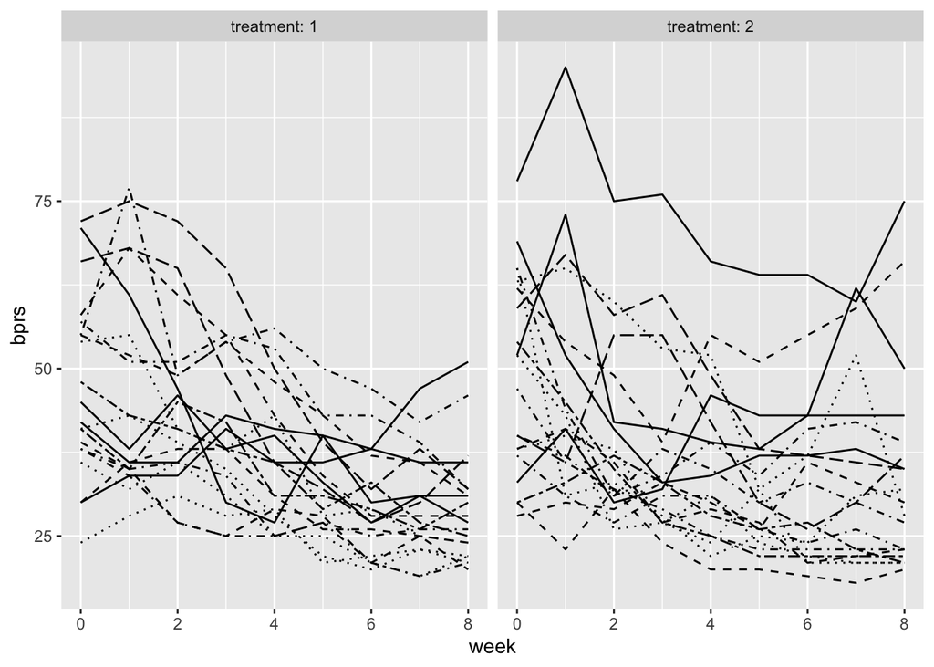

```r
library(ggplot2)
gg1<-ggplot(BPRSL, aes(x = week, y = bprs, linetype = subject)) +
  geom_line() +
  scale_linetype_manual(values = rep(1:10, times=4)) +
  facet_grid(. ~ treatment, labeller = label_both) +
  theme(legend.position = "none") +
  scale_y_continuous(limits = c(min(BPRSL$bprs), max(BPRSL$bprs)))
gg1
```

Both treatment methods seems to show decrease in bprs (psychiatric scale) by the end of the treatment.For me first method looks much promising then second one. Same time individuals with high starting values has the highest values even by the end of the treatment. But, we almost data scientists and should not trust eyes. Let’s use more reliable methods to find difference.

We expected to construct multiple linear regression model ignoring fact of repeated records.

```r
BPRS_reg <- lm(bprs ~ week + treatment, data = BPRSL)
summary(BPRS_reg)
```

```
##
## Call:
## lm(formula = bprs ~ week + treatment, data = BPRSL)
##
## Residuals:
##     Min      1Q  Median      3Q     Max
## -22.454  -8.965  -3.196   7.002  50.244
##
## Coefficients:
##             Estimate Std. Error t value Pr(>|t|)
## (Intercept)  46.4539     1.3670  33.982   <2e-16 ***
## week         -2.2704     0.2524  -8.995   <2e-16 ***
## treatment2    0.5722     1.3034   0.439    0.661
## ---
## Signif. codes:  0 '***' 0.001 '**' 0.01 '*' 0.05 '.' 0.1 ' ' 1
##
## Residual standard error: 12.37 on 357 degrees of freedom
## Multiple R-squared:  0.1851, Adjusted R-squared:  0.1806
## F-statistic: 40.55 on 2 and 357 DF,  p-value: < 2.2e-16
```

From linear regression could be seen that first treatment and week are significantly related with bprs. It is not a case for the first model.

Next step is to fit random intercept model with week and treatment method as explanatory variables.

```r
BPRS_ref <- lmer(bprs ~ week + treatment + (1 | subject), data = BPRSL, REML = FALSE)
summary(BPRS_ref)
```

```
## Linear mixed model fit by maximum likelihood  ['lmerMod']
## Formula: bprs ~ week + treatment + (1 | subject)
##    Data: BPRSL
##
##      AIC      BIC   logLik deviance df.resid
##   2748.7   2768.1  -1369.4   2738.7      355
##
## Scaled residuals:
##     Min      1Q  Median      3Q     Max
## -3.0481 -0.6749 -0.1361  0.4813  3.4855
##
## Random effects:
##  Groups   Name        Variance Std.Dev.
##  subject  (Intercept)  47.41    6.885
##  Residual             104.21   10.208
## Number of obs: 360, groups:  subject, 20
##
## Fixed effects:
##             Estimate Std. Error t value
## (Intercept)  46.4539     1.9090  24.334
## week         -2.2704     0.2084 -10.896
## treatment2    0.5722     1.0761   0.532
##
## Correlation of Fixed Effects:
##            (Intr) week
## week       -0.437
## treatment2 -0.282  0.000
```

Estimated variance (and SD) of subjects is relevantly low 47.41 (6.885). This could be interpreted as low variation in the intercepts. Estimated regression parameters are same as in model before. Standard errors are lower for second treatment and week, but higher for first treatment.

Next proposed is to fit random intercept and random slope model.This model will allow variables to have different slope.

```r
library(lme4)
BPRS_ref1 <- lmer(bprs ~ week + treatment + (week | subject), data = BPRSL, REML = FALSE)
summary(BPRS_ref1)
```

```
## Linear mixed model fit by maximum likelihood  ['lmerMod']
## Formula: bprs ~ week + treatment + (week | subject)
##    Data: BPRSL
##
##      AIC      BIC   logLik deviance df.resid
##   2745.4   2772.6  -1365.7   2731.4      353
##
## Scaled residuals:
##     Min      1Q  Median      3Q     Max
## -2.8919 -0.6194 -0.0691  0.5531  3.7976
##
## Random effects:
##  Groups   Name        Variance Std.Dev. Corr
##  subject  (Intercept) 64.8222  8.0512
##           week         0.9609  0.9802   -0.51
##  Residual             97.4305  9.8707
## Number of obs: 360, groups:  subject, 20
##
## Fixed effects:
##             Estimate Std. Error t value
## (Intercept)  46.4539     2.1052  22.066
## week         -2.2704     0.2977  -7.626
## treatment2    0.5722     1.0405   0.550
##
## Correlation of Fixed Effects:
##            (Intr) week
## week       -0.582
## treatment2 -0.247  0.000
```

Fitting Anova with both models.

```r
anova(BPRS_ref1, BPRS_ref)
```

```
## Data: BPRSL
## Models:
## BPRS_ref: bprs ~ week + treatment + (1 | subject)
## BPRS_ref1: bprs ~ week + treatment + (week | subject)
##           npar    AIC    BIC  logLik deviance  Chisq Df Pr(>Chisq)
## BPRS_ref     5 2748.7 2768.1 -1369.4   2738.7
## BPRS_ref1    7 2745.4 2772.6 -1365.7   2731.4 7.2721  2    0.02636 *
## ---
## Signif. codes:  0 '***' 0.001 '**' 0.01 '*' 0.05 '.' 0.1 ' ' 1
```

Significant p value (0.026) was seen for the Random Intercept model. This mean that model fit data better compare to intercept model. Another approach is to fit random intercept model with random slope and interaction between used treatment and week.

```r
BPRS_ref2 <- lmer(bprs ~ week * treatment + (week | subject), data = BPRSL, REML = FALSE)
summary(BPRS_ref2)
```

```
## Linear mixed model fit by maximum likelihood  ['lmerMod']
## Formula: bprs ~ week * treatment + (week | subject)
##    Data: BPRSL
##
##      AIC      BIC   logLik deviance df.resid
##   2744.3   2775.4  -1364.1   2728.3      352
##
## Scaled residuals:
##     Min      1Q  Median      3Q     Max
## -3.0512 -0.6271 -0.0768  0.5288  3.9260
##
## Random effects:
##  Groups   Name        Variance Std.Dev. Corr
##  subject  (Intercept) 64.9964  8.0620
##           week         0.9687  0.9842   -0.51
##  Residual             96.4707  9.8220
## Number of obs: 360, groups:  subject, 20
##
## Fixed effects:
##                 Estimate Std. Error t value
## (Intercept)      47.8856     2.2521  21.262
## week             -2.6283     0.3589  -7.323
## treatment2       -2.2911     1.9090  -1.200
## week:treatment2   0.7158     0.4010   1.785
##
## Correlation of Fixed Effects:
##             (Intr) week   trtmn2
## week        -0.650
## treatment2  -0.424  0.469
## wek:trtmnt2  0.356 -0.559 -0.840
```

Same, let’s fit anova with new random intercept models.

```r
anova(BPRS_ref2, BPRS_ref1)
```

```
## Data: BPRSL
## Models:
## BPRS_ref1: bprs ~ week + treatment + (week | subject)
## BPRS_ref2: bprs ~ week * treatment + (week | subject)
##           npar    AIC    BIC  logLik deviance  Chisq Df Pr(>Chisq)
## BPRS_ref1    7 2745.4 2772.6 -1365.7   2731.4
## BPRS_ref2    8 2744.3 2775.4 -1364.1   2728.3 3.1712  1    0.07495 .
## ---
## Signif. codes:  0 '***' 0.001 '**' 0.01 '*' 0.05 '.' 0.1 ' ' 1
```

New fitted model slightly better then old one. So let’s use it to create fitted values. Creating vector of fitted values.

```r
Fitted <- fitted(BPRS_ref2)
Fitted
```

[output not shown]

[output cut: 35 more lines]

[output not shown]

```r
# Create a new column fitted to RATSL
BPRSL$fitted<-Fitted
head(BPRSL)
```

```
##   treatment subject weeks bprs week   fitted
## 1         1       1 week0   42    0 49.24017
## 2         1       2 week0   58    0 46.97380
## 3         1       3 week0   54    0 47.65582
## 4         1       4 week0   55    0 49.85313
## 5         1       5 week0   72    0 66.39001
## 6         1       6 week0   48    0 42.59363
```

```r
BPRSL$fitted<-as.integer(BPRSL$fitted)
```

Plotting fitted values. Note first plot was already shown before.

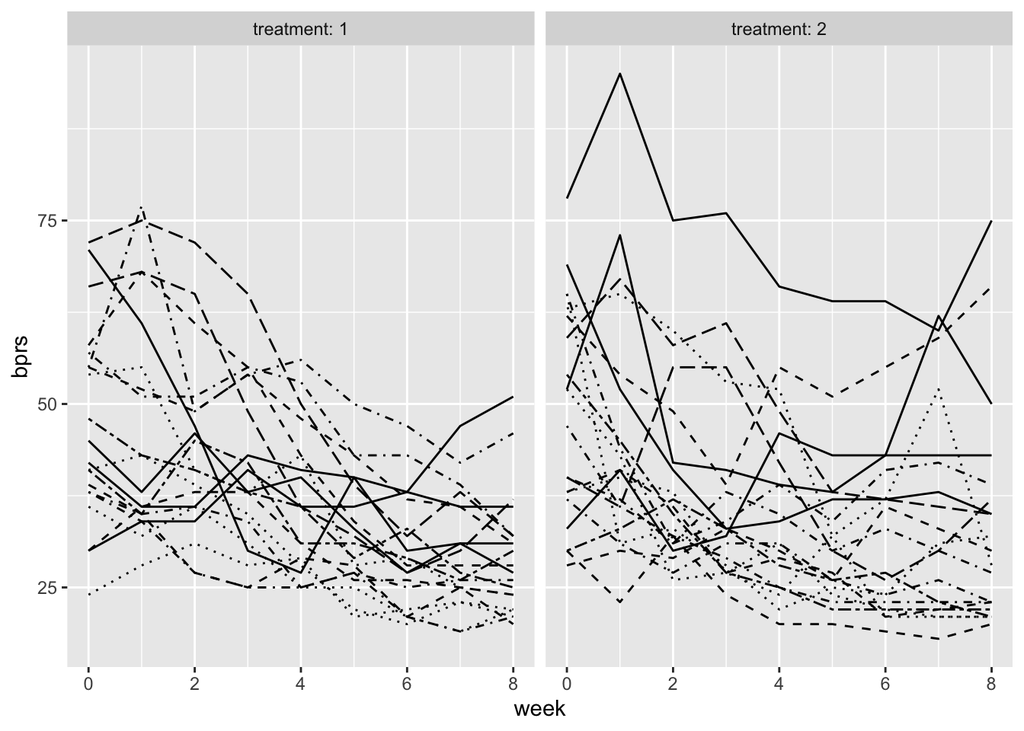

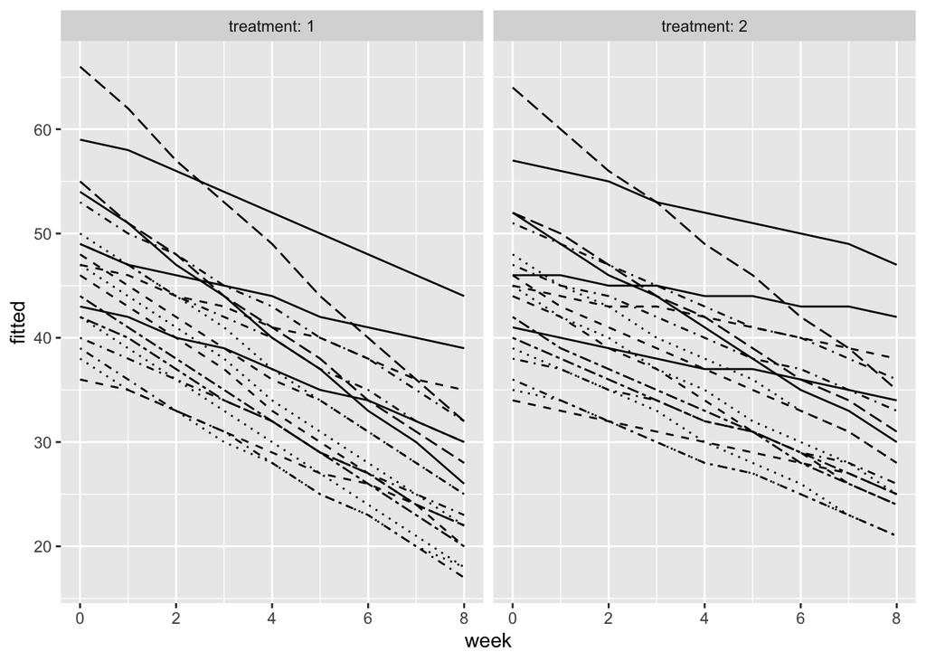

```r
par(mar = c(4, 4, .1, .1))
gg1
gg2<-ggplot(BPRSL, aes(x = week, y = fitted, linetype = subject)) +
  geom_line() +
  scale_linetype_manual(values = rep(1:10, times=4)) +
  facet_grid(. ~ treatment, labeller = label_both) +
  theme(legend.position = "none") +
  scale_y_continuous(limits = c(min(BPRSL$fitted), max(BPRSL$fitted)))
gg2
```